# Mcap_Acute_Exposure

HM Putnam

January 27, 2018

## Load packages and set options

# Coral Collection

##### Fragments of *Montipora capitata* (one per colony) were collected on 15 June 2016 from the fringing reefs of Kaneohe Bay, Oahu, Hawaii (21.429748, -157.793024) under SAP 2017-28. They were immediately returned to the Hawaii Institute of Marine Biology where they were placed in a 1,300L common garden tank with flowing seawater (Putnam et al 2016 DOI: 10.1111/eva.12408). Coral nubbins were formed by attaching the broken skeleton to plastic frag plugs using non toxic hot glue.

# Logger Calibration

##### Light and Temperature Loggers were calibrated to ensure standardization

# Coral Acclimation

##### Nubbins were acclimated for 15 days under ambient enviornmetnal conditions including natural diurnal fluctuations in pH, light, and temperature (e.g., Putnam et al 2016 DOI: 10.1111/eva.12408).

```r
Acclim.data <- read.csv("~/MyProjects/Montipora_Acute_Exp/RAnalysis/Data/Acclimation_Data.csv", header=TRUE, sep=",", na.strings="NA") #load data with a header, separated by commas, with NA as NA
Acclim.data[Acclim.data == 0] <- NA #replace 0 with NA
light <-(Acclim.data$Tank5.Light)/(15*60) #Assign light column in dataframe and convert to units of µmol m-2 s-1
light <-(light*L5.lm[2])+L5.lm[1] #Apply the cross calibration of the odyssey light to Licor cosine sensor standard 192SA cosine sensor
temp <-Acclim.data$Tank5.Temp #Assign temperature column in dataframe
temp <-(temp*T5.lm[2])+T5.lm[1] #Apply the cross calibration of temperature to standard logger #1
pH <- Acclim.data$Tank5.pH
Acc <- data.frame(Acclim.data$Date.Time, light, temp, pH) #combine light and temperature data
mydate <- strptime(Acc$Acclim.data.Date.Time, format="%m/%d/%y %H:%M") #convert date format to characters
quarterhours <- format(as.POSIXct(mydate) ,format = "%H:%M") #set time as every 15 min
Acc.data <- cbind(Acc, quarterhours) #make a dataframe out of data and new times
range(na.omit(Acc.data$temp)) #view data range
```

```
## [1] 25.54165 28.46009
```

```r
range(na.omit(Acc.data$light)) #view data range
```

```
## [1]   4.20058 432.47384
```

```r
range(na.omit(Acc.data$pH)) #view data range
```

```
## [1] 7.90 8.19
```

```r
#Tank Temperature Data for Acclimation Period (15 June 2016 - 29 June 2016)
quarterly.temp.mean <- aggregate(temp ~ quarterhours, data=Acc.data, mean, na.rm=TRUE) #calculate mean of temperature for every 15 min interval
quarterly.temp.se <- aggregate(temp ~ quarterhours, data=Acc.data, std.error, na.rm=TRUE) #calculate standard error of the mean of temperature for every 15 min interval
Acc.temp.N <- sum(!is.na(Acc.data$temp)) #Count sample size without NA values
Acc.temp.N #View data
```

```
## [1] 1438
```

```r
temp.means <- data.frame(quarterly.temp.mean, quarterly.temp.se$temp) #combine mean and standard error results
colnames(temp.means) <- c("Time", "mean", "se")  #rename columns to describe contents
range(na.omit(temp.means$mean)) #range of average temp levels
```

```
## [1] 25.98532 27.59986
```

```r
Acc.temp.m <- round(mean(na.omit(Acc.data$temp)), digits=2)
Acc.temp.se <-round(sd(na.omit(Acc.data$temp))/sqrt(length(na.omit(Acc.data$temp))), digits=2)

Acclimation.Temps <- cbind("Temperature", Acc.temp.m, Acc.temp.se)

#Tank Light Data for Acclimation Period (15 June 2016 - 29 June 2016)
quarterly.light.mean <- aggregate(light ~ quarterhours, data=Acc.data, mean, na.rm=TRUE) #calculate mean of lighterature for every 15 min interval
quarterly.light.mean <- rbind(c("06:00","0"), quarterly.light.mean) #combine rows
quarterly.light.se <- aggregate(light ~ quarterhours, data=Acc.data, std.error, na.rm=TRUE) #calculate standard error of the mean of lighterature for every 15 min interval
quarterly.light.se <- rbind(c("06:00","0"), quarterly.light.se) #combine rows
Acc.light.N <- sum(!is.na(Acc.data$light)) #Count sample size without NA values
Acc.light.N #View data
```

```
## [1] 85
```

```r
light.means <- data.frame(quarterly.light.mean, quarterly.light.se$light) #combine mean and standard error results
light.means[light.means  == 0] <- NA
colnames(light.means) <- c("Time", "mean", "se")  #rename columns to describe contents
light.means$mean <- as.numeric(light.means$mean)
light.means$se <- as.numeric(light.means$se)
range(na.omit(light.means$mean)) #range of average light levels
```

```
## [1]   4.20058 429.73827
```

```r
Acc.light.m <- round(mean(na.omit(Acc.data$light)), digits=1)
Acc.light.se <-round(sd(na.omit(Acc.data$light))/sqrt(length(na.omit(Acc.data$light))), digits=1)

Acclimation.light <- cbind("Light", Acc.light.m, Acc.light.se)

#Tank NBS pH Data for Acclimation Period (15 June 2016 - 29 June 2016)
quarterly.pH.mean <- aggregate(pH ~ quarterhours, data=Acc.data, mean, na.rm=TRUE) #calculate mean of pHerature for every 15 min interval
quarterly.pH.se <- aggregate(pH ~ quarterhours, data=Acc.data, std.error, na.rm=TRUE) #calculate standard error of the mean of pHerature for every 15 min interval
Acc.pH.N <- sum(!is.na(Acc.data$pH)) #Count sample size without NA values
Acc.pH.N #View data
```

```
## [1] 672
```

```r
pH.means <- data.frame(quarterly.pH.mean, quarterly.pH.se$pH) #combine mean and standard error results
colnames(pH.means) <- c("Time", "mean", "se")  #rename columns to describe contents
range(na.omit(pH.means$mean)) #range of average pH levels
```

```
## [1] 7.935714 8.124286
```

```r
Acc.pH.m <- round(mean(na.omit(Acc.data$pH)), digits=3)
Acc.pH.se <-round(sd(na.omit(Acc.data$pH))/sqrt(length(na.omit(Acc.data$pH))), digits=3)

Acclimation.pH <- cbind("pH", Acc.pH.m, Acc.pH.se)

Acc.Table <- rbind(Acclimation.Temps,Acclimation.light,Acclimation.pH)
colnames(Acc.Table) <- c("Parameter", "Mean", "SEM")
write.csv(Acc.Table, "~/MyProjects/Montipora_Acute_Exp/RAnalysis/Output/Acclimation_Conditions_20160615_20160630.csv")

Fig.Acc.Temp <- ggplot(temp.means) + #Plot average diurnal cycle of temperature data
  geom_point(aes(x = Time, y = mean), colour="black", cex=0.8) + #Plot points using time as the x axis, light as the Y axis and black dots
  geom_errorbar(aes(x=Time, ymax=mean+se, ymin=mean-se), position=position_dodge(0.9), data=temp.means, col="black", width=0) + #set values for standard error bars and offset on the X axis for clarity
  scale_x_discrete(breaks=c("01:00", "06:00", "12:00", "18:00", "23:00")) + #set discrete breaks on the X axis
  ggtitle("A) TEMPERATURE") + #Label the graph with the main title
  ylim(25,28) + #Set Y axis limits
  xlab("Time") + #Label the X Axis
  ylab("Temperature (°C)") + #Label the Y Axis
  theme_bw() + #Set the background color
  theme(axis.line = element_line(color = 'black'), #Set the axes color
        axis.ticks.length=unit(-0.2, "cm"), #turn ticks inward
        axis.text.y = element_text(margin=unit(c(0.5,0.5,0.5,0.5), "cm")), #set margins on labels
        axis.text.x = element_text(margin=unit(c(0.5,0.5,0.5,0.5), "cm"), angle = 90, vjust = 0.5, hjust=1), #set margins on labels
        panel.grid.major = element_blank(), #Set the major gridlines
        panel.grid.minor = element_blank(), #Set the minor gridlines
        plot.background=element_blank(), #Set the plot background
        panel.border=element_rect(size=1.25, fill = NA), #set outer border
        plot.title=element_text(hjust=0)) #Justify the title to the top left

Fig.Acc.Light <- ggplot(light.means) + #Plot average diurnal cycle of light data
  geom_point(aes(x = Time, y = mean), colour="black", cex=0.8) + #Plot points using time as the x axis, light as the Y axis and black dots
  geom_errorbar(aes(x=Time, ymax=mean+se, ymin=mean-se), position=position_dodge(0.9), data=light.means, col="black", width=0) + #set values for standard error bars and offset on the X axis for clarity
  scale_x_discrete(breaks=c("01:00", "06:00", "12:00", "18:00", "23:00")) + #set discrete breaks on the X axis
  ggtitle("B) LIGHT") + #Label the graph with the main title
  ylim(0,500) + #Set Y axis limits
  xlab("Time") + #Label the X Axis
  ylab(bquote('Irradiance ('*mu~'mol' ~ m^-2~s^-1*')')) + #Label the Y Axis
  theme_bw() + #Set the background color
  theme(axis.line = element_line(color = 'black'), #Set the axes color
        axis.ticks.length=unit(-0.2, "cm"), #turn ticks inward
        axis.text.y = element_text(margin=unit(c(0.5,0.5,0.5,0.5), "cm")), #set margins on labels
        axis.text.x = element_text(margin=unit(c(0.5,0.5,0.5,0.5), "cm"), angle = 90, vjust = 0.5, hjust=1), #set margins on labels
        panel.grid.major = element_blank(), #Set the major gridlines
        panel.grid.minor = element_blank(), #Set the minor gridlines
        plot.background=element_blank(), #Set the plot background
        panel.border=element_rect(size=1.25, fill = NA), #set outer border
        plot.title=element_text(hjust=0)) #Justify the title to the top left


Fig.Acc.pH <- ggplot(pH.means) + #Plot average diurnal cycle of temperature data
  geom_point(aes(x = Time, y = mean), colour="black", cex=0.8) + #Plot points using time as the x axis, light as the Y axis and black dots
  geom_errorbar(aes(x=Time, ymax=mean+se, ymin=mean-se), position=position_dodge(0.9), data=pH.means, col="black", width=0) + #set values for standard error bars and offset on the X axis for clarity
  scale_x_discrete(breaks=c("01:00", "06:00", "12:00", "18:00", "23:00")) + #set discrete breaks on the X axis
  ggtitle("C) pH") + #Label the graph with the main title
  ylim(7.8,8.2) + #Set Y axis limits
  xlab("Time") + #Label the X Axis
  ylab("pH (NBS)") + #Label the Y Axis
  theme_bw() + #Set the background color
  theme(axis.line = element_line(color = 'black'), #Set the axes color
        axis.ticks.length=unit(-0.2, "cm"), #turn ticks inward
        axis.text.y = element_text(margin=unit(c(0.5,0.5,0.5,0.5), "cm")), #set margins on labels
        axis.text.x = element_text(margin=unit(c(0.5,0.5,0.5,0.5), "cm"), angle = 90, vjust = 0.5, hjust=1), #set margins on labels
        panel.grid.major = element_blank(), #Set the major gridlines
        panel.grid.minor = element_blank(), #Set the minor gridlines
        plot.background=element_blank(), #Set the plot background
        panel.border=element_rect(size=1.25, fill = NA), #set outer border
        plot.title=element_text(hjust=0)) #Justify the title to the top left
```

# Coral Exposure

##### Three treatments conditions were created to look at the individual effects of increased temperature and pCO<sub>2</sub> on coral response. These included Ambient Temperature, Ambient CO<sub>2</sub> (ATAC), Ambient Temperature, High CO<sub>2</sub> (ATHC), and High Temperature, Ambient CO<sub>2</sub> (HTAC). Each treatment was replicated in three tanks, with 6 replicate nubbins in each tank (one per original collection colony) for the experimental time series. Nubbins were collected at 06:30 on 30 June 2016 for Time0, 07:30 for 1 hour of exposure, and 12:30 for six hours of exposure.

```r
#Tank Temperature Data for Adult Exposure Experimental Period (30 June 16)
tank.temp.data <- read.csv("~/MyProjects/Montipora_Acute_Exp/RAnalysis/Data/20160630_Tank_Temp_Data.csv", header=TRUE, sep=",", na.strings="NA", skip=1) #load data with a header, separated by commas, with NA as NA
mydate.tanks <- strptime(tank.temp.data$Date.Time, format="%m/%d/%y %H:%M") #convert date format to characters

#tank.temp.data$Tank4.cal <-(tank.temp.data$Tank4*T4.lm[2])+T4.lm[1] #Apply the cross calibration of temperature to standard logger
tank.temp.data$Tank6.cal <-(tank.temp.data$Tank6*T6.lm[2])+T6.lm[1] #Apply the cross calibration of temperature to standard logger
tank.temp.data$Tank9.cal <-(tank.temp.data$Tank9*T9.lm[2])+T9.lm[1] #Apply the cross calibration of temperature to standard logger
tank.temp.data$Tank11.cal <-(tank.temp.data$Tank11*T11.lm[2])+T11.lm[1] #Apply the cross calibration of temperature to standard logger
tank.temp.data$Tank12.cal <-(tank.temp.data$Tank12*T12.lm[2])+T12.lm[1] #Apply the cross calibration of temperature to standard logger
tank.temp.data$Tank13.cal <-(tank.temp.data$Tank13*T13.lm[2])+T13.lm[1] #Apply the cross calibration of temperature to standard logger
tank.temp.data$Tank14.cal <-(tank.temp.data$Tank14*T14.lm[2])+T14.lm[1] #Apply the cross calibration of temperature to standard logger
tank.temp.data$Tank15.cal <-(tank.temp.data$Tank15*T15.lm[2])+T15.lm[1] #Apply the cross calibration of temperature to standard logger
tank.temp.data$Tank16.cal <-(tank.temp.data$Tank16*T16.lm[2])+T16.lm[1] #Apply the cross calibration of temperature to standard logger

tank.tempdata <-data.frame(mydate.tanks, tank.temp.data$Tank6.cal, tank.temp.data$Tank9.cal, tank.temp.data$Tank11.cal, tank.temp.data$Tank12.cal, tank.temp.data$Tank13.cal, tank.temp.data$Tank14.cal, tank.temp.data$Tank15.cal, tank.temp.data$Tank16.cal, tank.temp.data$T1, tank.temp.data$T6) #make a dataframe of temperature and time
colnames(tank.tempdata) <- c("Date.Time", "Tank6", "Tank9", "Tank11", "Tank12", "Tank13", "Tank14", "Tank15", "Tank16")

#One Hour Exposure Means by Treatment
HTAC.temp.mean.T1 <- round(mean(na.omit(tank.tempdata$Tank6[1:5], tank.tempdata$Tank9[1:5])), digits=2)
HTAC.temp.se.T1 <-round(sd(na.omit(tank.tempdata$Tank6[1:5], tank.tempdata$Tank9[1:5]))/sqrt(length(na.omit(tank.tempdata$Tank6[1:5], tank.tempdata$Tank9[1:5]))), digits=2)

ATAC.temp.mean.T1 <- round(mean(na.omit(tank.tempdata$Tank11[1:5], tank.tempdata$Tank14[1:5], tank.tempdata$Tank15[1:5])), digits=2)
ATAC.temp.se.T1 <-round(sd(na.omit(tank.tempdata$Tank11[1:5], tank.tempdata$Tank14[1:5], tank.tempdata$Tank15[1:5]))/sqrt(length(na.omit(tank.tempdata$Tank11[1:5], tank.tempdata$Tank14[1:5], tank.tempdata$Tank15[1:5]))), digits=2)

ATHC.temp.mean.T1 <- round(mean(na.omit(tank.tempdata$Tank12[1:5], tank.tempdata$Tank13[1:5], tank.tempdata$Tank16[1:5])), digits=2)
ATHC.temp.se.T1 <-round(sd(na.omit(tank.tempdata$Tank12[1:5], tank.tempdata$Tank13[1:5], tank.tempdata$Tank16[1:5]))/sqrt(length(na.omit(tank.tempdata$Tank12[1:5], tank.tempdata$Tank13[1:5], tank.tempdata$Tank16[1:5]))), digits=2)

#Six Hour Exposure Means
HTAC.temp.mean.T6 <- round(mean(na.omit(tank.tempdata$Tank6, tank.tempdata$Tank9)), digits=2)
HTAC.temp.se.T6 <-round(sd(na.omit(tank.tempdata$Tank6, tank.tempdata$Tank9))/sqrt(length(na.omit(tank.tempdata$Tank6, tank.tempdata$Tank9))), digits=2)

ATAC.temp.mean.T6 <- round(mean(na.omit(tank.tempdata$Tank11, tank.tempdata$Tank14, tank.tempdata$Tank15)), digits=2)
ATAC.temp.se.T6 <-round(sd(na.omit(tank.tempdata$Tank11, tank.tempdata$Tank14, tank.tempdata$Tank15))/sqrt(length(na.omit(tank.tempdata$Tank11, tank.tempdata$Tank14, tank.tempdata$Tank15))), digits=2)

ATHC.temp.mean.T6 <- round(mean(na.omit(tank.tempdata$Tank12, tank.tempdata$Tank13, tank.tempdata$Tank16)), digits=2)
ATHC.temp.se.T6 <-round(sd(na.omit(tank.tempdata$Tank12, tank.tempdata$Tank13, tank.tempdata$Tank16))/sqrt(length(na.omit(tank.tempdata$Tank12, tank.tempdata$Tank13, tank.tempdata$Tank16))), digits=2)

Exposure.Temp.Mean.T1 <- rbind(ATAC.temp.mean.T1, ATHC.temp.mean.T1, HTAC.temp.mean.T1)
Exposure.Temp.SE.T1 <- rbind(ATAC.temp.se.T1, ATHC.temp.se.T1, HTAC.temp.se.T1)
Exposure.Temp.Mean.T6 <- rbind(ATAC.temp.mean.T6, ATHC.temp.mean.T6, HTAC.temp.mean.T6)
Exposure.Temp.SE.T6 <- rbind(ATAC.temp.se.T6, ATHC.temp.se.T6, HTAC.temp.se.T6)

Exp.Temp.Table <- cbind(Exposure.Temp.Mean.T1,Exposure.Temp.SE.T1,Exposure.Temp.Mean.T6,Exposure.Temp.SE.T6)
colnames(Exp.Temp.Table) <- c("T1.Temp.Mean", "T1.Temp.SEM","T6.Temp.Mean", "T6.Temp.SEM")
rownames(Exp.Temp.Table) <- c("ATAC", "ATHC", "HTAC")
write.csv(Exp.Temp.Table, "~/MyProjects/Montipora_Acute_Exp/RAnalysis/Output/Exposure_Temp_Conditions_2016030.csv")

# Exposure Temperature Means °C
Exp.Temp.Table
```

```
##      T1.Temp.Mean T1.Temp.SEM T6.Temp.Mean T6.Temp.SEM
## ATAC        26.87        0.01        27.14        0.06
## ATHC        26.93        0.01        27.33        0.08
## HTAC        28.67        0.01        29.05        0.08
```

```r
#Tank Light Data for Adult Exposure Experimental Period (30 June 16)
tank.light.data <- read.csv("~/MyProjects/Montipora_Acute_Exp/RAnalysis/Data/20160630_Tank_Light_Data.csv", header=TRUE, sep=",", na.strings="NA", skip=1) #load data with a header, separated by commas, with NA as NA
mydate.tanks <- strptime(tank.light.data$Date.Time, format="%m/%d/%y %H:%M") #convert date format to characters

tank.light.data$Tank4.cal <-((tank.light.data$Tank4/(15*60))*L5.lm[2])+L5.lm[1] #Apply the cross calibration of light to standard logger
tank.light.data$Tank6.cal <-((tank.light.data$Tank6/(15*60))*L6.lm[2])+L6.lm[1] #Apply the cross calibration of light to standard logger
tank.light.data$Tank9.cal <-((tank.light.data$Tank9/(15*60))*L9.lm[2])+L9.lm[1] #Apply the cross calibration of lightto standard logger
tank.light.data$Tank11.cal <-((tank.light.data$Tank11/(15*60))*L11.lm[2])+L11.lm[1] #Apply the cross calibration of light to standard logger
tank.light.data$Tank12.cal <-((tank.light.data$Tank12/(15*60))*T12.lm[2])+T12.lm[1] #Apply the cross calibration of light to standard logger
tank.light.data$Tank13.cal <-((tank.light.data$Tank13/(15*60))*L13.lm[2])+L13.lm[1] #Apply the cross calibration of light to standard logger
tank.light.data$Tank14.cal <-((tank.light.data$Tank14/(15*60))*L14.lm[2])+L14.lm[1] #Apply the cross calibration of light to standard logger
tank.light.data$Tank15.cal <-((tank.light.data$Tank15/(15*60))*L15.lm[2])+L15.lm[1] #Apply the cross calibration of light to standard logger
tank.light.data$Tank16.cal <-((tank.light.data$Tank16/(15*60))*L16.lm[2])+L16.lm[1] #Apply the cross calibration of light to standard logger

tank.lightdata <-data.frame(mydate.tanks, tank.light.data$Tank4.cal, tank.light.data$Tank6.cal, tank.light.data$Tank9.cal, tank.light.data$Tank11.cal, tank.light.data$Tank12.cal, tank.light.data$Tank13.cal, tank.light.data$Tank14.cal, tank.light.data$Tank15.cal, tank.light.data$Tank16.cal, tank.light.data$T1, tank.light.data$T6) #make a dataframe of lighterature and time
colnames(tank.lightdata) <- c("Date.Time", "Tank4", "Tank6", "Tank9", "Tank11", "Tank12", "Tank13", "Tank14", "Tank15", "Tank16")

#One Hour Exposure Means by Treatment
HTAC.light.mean.T1 <- round(mean(na.omit(tank.lightdata$Tank4[1:5],tank.lightdata$Tank6[1:5], tank.lightdata$Tank9[1:5])), digits=1)
HTAC.light.se.T1 <-round(sd(na.omit(tank.lightdata$Tank4[1:5],tank.lightdata$Tank6[1:5], tank.lightdata$Tank9[1:5]))/sqrt(length(na.omit(tank.lightdata$Tank4[1:5],tank.lightdata$Tank6[1:5], tank.lightdata$Tank9[1:5]))), digits=1)

ATAC.light.mean.T1 <- round(mean(na.omit(tank.lightdata$Tank11[1:5], tank.lightdata$Tank14[1:5], tank.lightdata$Tank15[1:5])), digits=1)
ATAC.light.se.T1 <-round(sd(na.omit(tank.lightdata$Tank11[1:5], tank.lightdata$Tank14[1:5], tank.lightdata$Tank15[1:5]))/sqrt(length(na.omit(tank.lightdata$Tank11[1:5], tank.lightdata$Tank14[1:5], tank.lightdata$Tank15[1:5]))), digits=1)

ATHC.light.mean.T1 <- round(mean(na.omit(tank.lightdata$Tank12[1:5], tank.lightdata$Tank13[1:5], tank.lightdata$Tank16[1:5])), digits=1)
ATHC.light.se.T1 <-round(sd(na.omit(tank.lightdata$Tank12[1:5], tank.lightdata$Tank13[1:5], tank.lightdata$Tank16[1:5]))/sqrt(length(na.omit(tank.lightdata$Tank12[1:5], tank.lightdata$Tank13[1:5], tank.lightdata$Tank16[1:5]))), digits=1)

#Six Hour Exposure Means
HTAC.light.mean.T6 <- round(mean(na.omit(tank.lightdata$Tank6, tank.lightdata$Tank9)), digits=1)
HTAC.light.se.T6 <-round(sd(na.omit(tank.lightdata$Tank6, tank.lightdata$Tank9))/sqrt(length(na.omit(tank.lightdata$Tank6, tank.lightdata$Tank9))), digits=1)

ATAC.light.mean.T6 <- round(mean(na.omit(tank.lightdata$Tank11, tank.lightdata$Tank14, tank.lightdata$Tank15)), digits=1)
ATAC.light.se.T6 <-round(sd(na.omit(tank.lightdata$Tank11, tank.lightdata$Tank14, tank.lightdata$Tank15))/sqrt(length(na.omit(tank.lightdata$Tank11, tank.lightdata$Tank14, tank.lightdata$Tank15))), digits=1)

ATHC.light.mean.T6 <- round(mean(na.omit(tank.lightdata$Tank12, tank.lightdata$Tank13, tank.lightdata$Tank16)), digits=1)
ATHC.light.se.T6 <-round(sd(na.omit(tank.lightdata$Tank12, tank.lightdata$Tank13, tank.lightdata$Tank16))/sqrt(length(na.omit(tank.lightdata$Tank12, tank.lightdata$Tank13, tank.lightdata$Tank16))), digits=1)

Exposure.light.Mean.T1 <- rbind(ATAC.light.mean.T1, ATHC.light.mean.T1, HTAC.light.mean.T1)
Exposure.light.SE.T1 <- rbind(ATAC.light.se.T1, ATHC.light.se.T1, HTAC.light.se.T1)
Exposure.light.Mean.T6 <- rbind(ATAC.light.mean.T6, ATHC.light.mean.T6, HTAC.light.mean.T6)
Exposure.light.SE.T6 <- rbind(ATAC.light.se.T6, ATHC.light.se.T6, HTAC.light.se.T6)

Exp.light.Table <- cbind(Exposure.light.Mean.T1,Exposure.light.SE.T1,Exposure.light.Mean.T6,Exposure.light.SE.T6)
colnames(Exp.light.Table) <- c("T1.light.Mean", "T1.light.SEM","T6.light.Mean", "T6.light.SEM")
rownames(Exp.light.Table) <- c("ATAC", "ATHC", "HTAC")
write.csv(Exp.light.Table, "~/MyProjects/Montipora_Acute_Exp/RAnalysis/Output/Exposure_Conditions_Light_2016030.csv")

# Exposure Light Means µmol m-2 s-1
Exp.light.Table
```

```
##      T1.light.Mean T1.light.SEM T6.light.Mean T6.light.SEM
## ATAC           NaN           NA           NaN           NA
## ATHC           NaN           NA           NaN           NA
## HTAC           8.4          4.3         184.7         25.7
```

```r
#Tank pH Data for Adult Exposure Experimental Period (30 June 16)
tank.pH.data <- read.csv("~/MyProjects/Montipora_Acute_Exp/RAnalysis/Data/20160630_Tank_pH_Data.csv", header=TRUE, sep=",", na.strings="NA", skip=1) #load data with a header, separated by commas, with NA as NA
tank.pH.data$Date.Time <- strptime(tank.pH.data$Date.Time, format="%m/%d/%y %H:%M") #convert date format to characters

#One Hour Exposure Means by Treatment
HTAC.pH.mean.T1 <- round(mean(na.omit(tank.pH.data$Tank4[1:5],tank.pH.data$Tank6[1:5], tank.pH.data$Tank9[1:5])), digits=3)
HTAC.pH.se.T1 <-round(sd(na.omit(tank.pH.data$Tank4[1:5],tank.pH.data$Tank6[1:5], tank.pH.data$Tank9[1:5]))/sqrt(length(na.omit(tank.pH.data$Tank4[1:5],tank.pH.data$Tank6[1:5], tank.pH.data$Tank9[1:5]))), digits=3)

ATAC.pH.mean.T1 <- round(mean(na.omit(tank.pH.data$Tank11[1:5], tank.pH.data$Tank14[1:5], tank.pH.data$Tank15[1:5])), digits=3)
ATAC.pH.se.T1 <-round(sd(na.omit(tank.pH.data$Tank11[1:5], tank.pH.data$Tank14[1:5], tank.pH.data$Tank15[1:5]))/sqrt(length(na.omit(tank.pH.data$Tank11[1:5], tank.pH.data$Tank14[1:5], tank.pH.data$Tank15[1:5]))), digits=3)

ATHC.pH.mean.T1 <- round(mean(na.omit(tank.pH.data$Tank12[1:5], tank.pH.data$Tank13[1:5], tank.pH.data$Tank16[1:5])), digits=3)
ATHC.pH.se.T1 <-round(sd(na.omit(tank.pH.data$Tank12[1:5], tank.pH.data$Tank13[1:5], tank.pH.data$Tank16[1:5]))/sqrt(length(na.omit(tank.pH.data$Tank12[1:5], tank.pH.data$Tank13[1:5], tank.pH.data$Tank16[1:5]))), digits=3)

#Six Hour Exposure Means
HTAC.pH.mean.T6 <- round(mean(na.omit(tank.pH.data$Tank4, tank.pH.data$Tank6, tank.pH.data$Tank9)), digits=3)
HTAC.pH.se.T6 <-round(sd(na.omit(tank.pH.data$Tank4, tank.pH.data$Tank6, tank.pH.data$Tank9))/sqrt(length(na.omit(tank.pH.data$Tank4, tank.pH.data$Tank6, tank.pH.data$Tank9))), digits=3)

ATAC.pH.mean.T6 <- round(mean(na.omit(tank.pH.data$Tank11, tank.pH.data$Tank14, tank.pH.data$Tank15)), digits=3)
ATAC.pH.se.T6 <-round(sd(na.omit(tank.pH.data$Tank11, tank.pH.data$Tank14, tank.pH.data$Tank15))/sqrt(length(na.omit(tank.pH.data$Tank11, tank.pH.data$Tank14, tank.pH.data$Tank15))), digits=3)

ATHC.pH.mean.T6 <- round(mean(na.omit(tank.pH.data$Tank12, tank.pH.data$Tank13, tank.pH.data$Tank16)), digits=3)
ATHC.pH.se.T6 <-round(sd(na.omit(tank.pH.data$Tank12, tank.pH.data$Tank13, tank.pH.data$Tank16))/sqrt(length(na.omit(tank.pH.data$Tank12, tank.pH.data$Tank13, tank.pH.data$Tank16))), digits=3)

Exposure.pH.Mean.T1 <- rbind(ATAC.pH.mean.T1, ATHC.pH.mean.T1, HTAC.pH.mean.T1)
Exposure.pH.SE.T1 <- rbind(ATAC.pH.se.T1, ATHC.pH.se.T1, HTAC.pH.se.T1)
Exposure.pH.Mean.T6 <- rbind(ATAC.pH.mean.T6, ATHC.pH.mean.T6, HTAC.pH.mean.T6)
Exposure.pH.SE.T6 <- rbind(ATAC.pH.se.T6, ATHC.pH.se.T6, HTAC.pH.se.T6)

Exp.pH.Table <- cbind(Exposure.pH.Mean.T1,Exposure.pH.SE.T1,Exposure.pH.Mean.T6,Exposure.pH.SE.T6)
colnames(Exp.pH.Table) <- c("T1.pH.Mean", "T1.pH.SEM","T6.pH.Mean", "T6.pH.SEM")
rownames(Exp.pH.Table) <- c("ATAC", "ATHC", "HTAC")
write.csv(Exp.pH.Table, "~/MyProjects/Montipora_Acute_Exp/RAnalysis/Output/Exposure_Conditions_pH_2016030.csv")

# Exposure pH Means NBS
Exp.pH.Table
```

```
##      T1.pH.Mean T1.pH.SEM T6.pH.Mean T6.pH.SEM
## ATAC      7.922     0.002      7.981     0.011
## ATHC      7.652     0.002      7.709     0.010
## HTAC        NaN        NA        NaN        NA
```

```r
#Plotting Figures
T1s <- strptime("2016-06-30 06:30:00", "%Y-%m-%d %H:%M:%S")
T1e <- strptime("2016-06-30 07:30:00", "%Y-%m-%d %H:%M:%S")
T6e <- strptime("2016-06-30 12:30:00", "%Y-%m-%d %H:%M:%S")

#Temperature
Fig.Exposure.Temp <- ggplot(tank.tempdata) + #Plot average diurnal cycle of temperature data
  geom_rect(aes(xmin = T1s, xmax= T6e, ymin=26, ymax=26.2), fill="lightgray", alpha= 0.2) + #shade exposure time
  geom_rect(aes(xmin = T1s, xmax= T1e, ymin=26, ymax=26.2), fill="darkgray", alpha= 0.2) + #shade exposure time
  geom_point(aes(x = Date.Time, y = Tank6), colour="red", pch=16, cex=0.8) + #Plot points using time as the x axis, light as the Y axis and black dots
  geom_point(aes(x = Date.Time, y = Tank9), colour="red", pch=16, cex=0.8) + #Plot points using time as the x axis, light as the Y axis and black dots
  geom_point(aes(x = Date.Time, y = Tank11), colour="blue", pch=16, cex=0.8) + #Plot points using time as the x axis, light as the Y axis and black dots
  geom_point(aes(x = Date.Time, y = Tank12), colour="blue", pch=16, cex=0.8) + #Plot points using time as the x axis, light as the Y axis and black dots
  geom_point(aes(x = Date.Time, y = Tank13), colour="blue", pch=16, cex=0.8) + #Plot points using time as the x axis, light as the Y axis and black dots
  geom_point(aes(x = Date.Time, y = Tank14), colour="blue", pch=16, cex=0.8) + #Plot points using time as the x axis, light as the Y axis and black dots
  geom_point(aes(x = Date.Time, y = Tank15), colour="blue", pch=16, cex=0.8) + #Plot points using time as the x axis, light as the Y axis and black dots
  geom_point(aes(x = Date.Time, y = Tank16), colour="blue", pch=16, cex=0.8) + #Plot points using time as the x axis, light as the Y axis and black dots
  ggtitle("D) TEMPERATURE") + #Label the graph with the main title
  ylim(26,30) + #Set Y axis limits
  xlab("Time") + #Label the X Axis
  ylab("Temperature (°C)") + #Label the Y Axis
  theme_bw() + #Set the background color
  theme(axis.line = element_line(color = 'black'), #Set the axes color
        axis.ticks.length=unit(-0.2, "cm"), #turn ticks inward
        axis.text.y = element_text(margin=unit(c(0.5,0.5,0.5,0.5), "cm")), #set margins on labels
        axis.text.x = element_text(margin=unit(c(0.5,0.5,0.5,0.5), "cm"), angle = 90, vjust = 0.5, hjust=1), #set margins on labels
        panel.grid.major = element_blank(), #Set the major gridlines
        panel.grid.minor = element_blank(), #Set the minor gridlines
        plot.background=element_blank(), #Set the plot background
        panel.border=element_rect(size=1.25, fill = NA), #set outer border
        legend.key = element_blank(), #Set plot legend key
        plot.title=element_text(hjust=0)) #Justify the title to the top left

#Light
Fig.Exposure.Light <- ggplot(tank.lightdata) + #Plot average diurnal cycle of temperature data
    geom_rect(aes(xmin = T1s, xmax= T6e, ymin=-10, ymax=10), fill="lightgray", alpha= 0.2) + #shade exposure time
  geom_rect(aes(xmin = T1s, xmax= T1e, ymin=-10, ymax=10), fill="darkgray", alpha= 0.2) + #shade exposure time
  geom_point(aes(x = Date.Time, y = Tank4), colour="pink", pch=16, cex=0.8) + #Plot points using time as the x axis, light as the Y axis and black dots
  geom_point(aes(x = Date.Time, y = Tank6), colour="red", pch=16, cex=0.8) + #Plot points using time as the x axis, light as the Y axis and black dots
  geom_point(aes(x = Date.Time, y = Tank9), colour="darkred", pch=16, cex=0.8) + #Plot points using time as the x axis, light as the Y axis and black dots
  geom_point(aes(x = Date.Time, y = Tank11), colour="blue", pch=16, cex=0.8) + #Plot points using time as the x axis, light as the Y axis and black dots
  geom_point(aes(x = Date.Time, y = Tank12), colour="blue", pch=16, cex=0.8) + #Plot points using time as the x axis, light as the Y axis and black dots
  geom_point(aes(x = Date.Time, y = Tank13), colour="blue", pch=16, cex=0.8) + #Plot points using time as the x axis, light as the Y axis and black dots
  geom_point(aes(x = Date.Time, y = Tank14), colour="blue", pch=16, cex=0.8) + #Plot points using time as the x axis, light as the Y axis and black dots
  geom_point(aes(x = Date.Time, y = Tank15), colour="blue", pch=16, cex=0.8) + #Plot points using time as the x axis, light as the Y axis and black dots
  geom_point(aes(x = Date.Time, y = Tank16), colour="blue", pch=16, cex=0.8) + #Plot points using time as the x axis, light as the Y axis and black dots
  ggtitle("E) LIGHT") + #Label the graph with the main title
  ylim(-10,600) + #Set Y axis limits
  xlab("Time") + #Label the X Axis
  ylab(bquote('Irradiance ('*mu~'mol' ~ m^-2~s^-1*')')) + #Label the Y Axis
  theme_bw() + #Set the background color
  theme(axis.line = element_line(color = 'black'), #Set the axes color
        axis.ticks.length=unit(-0.2, "cm"), #turn ticks inward
        axis.text.y = element_text(margin=unit(c(0.5,0.5,0.5,0.5), "cm")), #set margins on labels
        axis.text.x = element_text(margin=unit(c(0.5,0.5,0.5,0.5), "cm"), angle = 90, vjust = 0.5, hjust=1), #set margins on labels
        panel.grid.major = element_blank(), #Set the major gridlines
        panel.grid.minor = element_blank(), #Set the minor gridlines
        plot.background=element_blank(), #Set the plot background
        panel.border=element_rect(size=1.25, fill = NA), #set outer border
        legend.key = element_blank(), #Set plot legend key
        plot.title=element_text(hjust=0)) #Justify the title to the top left

#pH
Fig.Exposure.pH <- ggplot(tank.pH.data) + #Plot average diurnal cycle of temperature data
    geom_rect(aes(xmin = T1s, xmax= T6e, ymin=7.5, ymax=7.55), fill="lightgray", alpha= 0.2) + #shade exposure time
  geom_rect(aes(xmin = T1s, xmax= T1e, ymin=7.5, ymax=7.55), fill="darkgray", alpha= 0.2) + #shade exposure time
  #geom_point(aes(x = Date.Time, y = Tank4), colour="pink", pch=16, cex=0.8) + #Plot points using time as the x axis, light as the Y axis and black dots
  #geom_point(aes(x = Date.Time, y = Tank6), colour="red", pch=16, cex=0.8) + #Plot points using time as the x axis, light as the Y axis and black dots
  #geom_point(aes(x = Date.Time, y = Tank9), colour="darkred", pch=16, cex=0.8) + #Plot points using time as the x axis, light as the Y axis and black dots
  geom_point(aes(x = Date.Time, y = Tank11), colour="blue", pch=16, cex=0.8) + #Plot points using time as the x axis, light as the Y axis and black dots
  geom_point(aes(x = Date.Time, y = Tank12), colour="blue", pch=16, cex=0.8) + #Plot points using time as the x axis, light as the Y axis and black dots
  geom_point(aes(x = Date.Time, y = Tank13), colour="blue", pch=16, cex=0.8) + #Plot points using time as the x axis, light as the Y axis and black dots
  geom_point(aes(x = Date.Time, y = Tank14), colour="blue", pch=16, cex=0.8) + #Plot points using time as the x axis, light as the Y axis and black dots
  geom_point(aes(x = Date.Time, y = Tank15), colour="blue", pch=16, cex=0.8) + #Plot points using time as the x axis, light as the Y axis and black dots
  geom_point(aes(x = Date.Time, y = Tank16), colour="blue", pch=16, cex=0.8) + #Plot points using time as the x axis, light as the Y axis and black dots
  ggtitle("F) pH") + #Label the graph with the main title
  ylim(7.5,8.5) + #Set Y axis limits
  xlab("Time") + #Label the X Axis
  ylab("pH (NBS)") + #Label the Y Axis
  theme_bw() + #Set the background color
  theme(axis.line = element_line(color = 'black'), #Set the axes color
        axis.ticks.length=unit(-0.2, "cm"), #turn ticks inward
        axis.text.y = element_text(margin=unit(c(0.5,0.5,0.5,0.5), "cm")), #set margins on labels
        axis.text.x = element_text(margin=unit(c(0.5,0.5,0.5,0.5), "cm"), angle = 90, vjust = 0.5, hjust=1), #set margins on labels
        panel.grid.major = element_blank(), #Set the major gridlines
        panel.grid.minor = element_blank(), #Set the minor gridlines
        plot.background=element_blank(), #Set the plot background
        panel.border=element_rect(size=1.25, fill = NA), #set outer border
        legend.key = element_blank(), #Set plot legend key
        plot.title=element_text(hjust=0)) #Justify the title to the top left
```

# Plotting

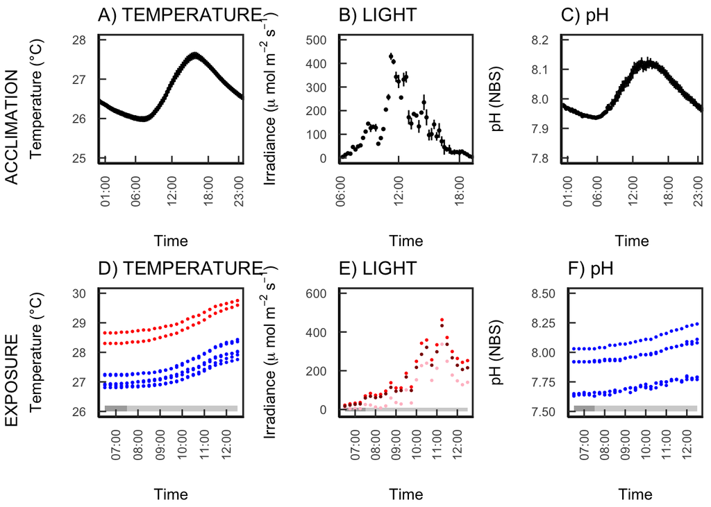